# Timeseries plot of Swiss residents

Sara

2022-01-16

# Introduction - what was the task?

As part of the [Data visualisation and communication course](https://www.extensionschool.ch/applied-data-science-communication-visualization), one of the optional tasks after finishing the first of four sub-courses was to find timeseries data and plot it. A very open question! There is so much timeseries data - the vast majority of at least the academic data I have worked with were timeseries. I need to choose something, so somewhat randomly I choose something I haven’t worked with before, namely open government data. I want to look at the number of people living in Switzerland - Swiss nationals and foreigners - but additionally show what proportion of the Swiss nationals has/had the right to vote. This could later be compared and contrasted with e.g. the numbers of signatures required for a referendum.

# Getting ready

with package imports

```r
library(tidyverse)
library(readxl)
library(scales)
```

## Data sources

all data come from the [Swiss Federal Statistical Office](https://www.bfs.admin.ch/bfs/de/home.html)

- [Share of Swiss nationals 1951 to 2020](https://www.bfs.admin.ch/bfs/de/home/statistiken/bevoelkerung/stand-entwicklung/bevoelkerung.assetdetail.18344337.html)
- [Share of non-Swiss nationals living in Switzerland 1951 to 2020](https://www.bfs.admin.ch/bfs/de/home/statistiken/bevoelkerung/stand-entwicklung/bevoelkerung.assetdetail.18344345.html)
- [share of people allowed to vote](https://www.bfs.admin.ch/bfs/de/home/statistiken/politik.assetdetail.11048403.html) {Number of signatures required for a referendum described here}(https://hls-dhs-dss.ch/de/articles/010386/2016-07-18/)

## reading and first preparation of data

```r
swiss <- read_excel("./data/su-d-01.02.04.02.xlsx", skip=3)
```

```
## * `` -> ...1
## * `` -> ...4
## * wanderung -> wanderung...6
## * wanderung -> wanderung...7
## * `` -> ...12
## * ...
```

```r
swiss <- swiss %>%
  rename(year = 1, pop_beginning = 2, pop_end = 11) %>% # rename and select columns
  dplyr::select(year, pop_beginning, pop_end) %>%
  filter(str_detect(year, "^[0-9]{4}$")) %>%
  mutate(year = as.integer(year))
glimpse(swiss)
```

```
## Rows: 68
## Columns: 3
## $ year          <int> 1951, 1952, 1953, 1954, 1955, 1956, 1957, 1958, 1959, 19~
## $ pop_beginning <dbl> 4432100, 4470800, 4513200, 4553100, 4593500, 4634000, 46~
## $ pop_end       <dbl> 4470800, 4513200, 4553100, 4593500, 4634000, 4674900, 47~
```

```r
non_swiss <- read_excel("./data/su-d-01.02.04.03.xlsx", skip = 3)
```

```
## * `` -> ...1
## * `` -> ...4
## * `` -> ...6
## * `` -> ...7
## * `` -> ...12
## * ...
```

```r
non_swiss <- non_swiss %>%
  rename(year = 1, pop_beginning = 2, pop_end = 11) %>% # rename and select columns
  dplyr::select(year, pop_beginning, pop_end) %>%
  filter(str_detect(year, "^[0-9]{4}$")) %>%
  mutate(year = as.integer(year))

glimpse(non_swiss)
```

```
## Rows: 68
## Columns: 3
## $ year          <int> 1951, 1952, 1953, 1954, 1955, 1956, 1957, 1958, 1959, 19~
## $ pop_beginning <dbl> 285100, 308100, 330900, 353900, 376800, 399700, 422500, ~
## $ pop_end       <dbl> 308100, 330900, 353900, 376800, 399700, 422500, 445300, ~
```

```r
voters <- read_excel("./data/su-d-17.02.02.04.01.xlsx", skip = 1)
```

```
## * `` -> ...2
```

```r
voters <- voters %>%
  rename(year = 1, population = 3, right_to_vote = 4, voting = 5, proportion_voted = 6) %>%
  select(-2)
glimpse(voters)
```

```
## Rows: 46
## Columns: 5
## $ year             <chr> NA, "1919", "1922", "1925", "1928", "1931", NA, "1935~
## $ population       <chr> NA, "3869200", "3926500", "3987000", "4037700", "4088~
## $ right_to_vote    <dbl> NA, 946271, 983238, 995551, 1043823, 1118841, NA, 119~
## $ voting           <dbl> NA, 760600, 750859, 764594, 822389, 881936, NA, 93575~
## $ proportion_voted <dbl> NA, 80.37867, 76.36595, 76.80109, 78.78625, 78.82586,~
```

There are annotations added as e.g. “4)” at the end of an existing data cell, e.g. for year 1939 or the population in 2019. I do not mind losing the 1939 data as some cantons apparently were missing and the numbers take an awkward drop. I’d rather keep the 2019 data though…

```r
voters <- voters %>%
  tidyr::separate(population, into = c("population", "addendum"), sep="[[:space:]]")
glimpse(voters)
```

```
## Rows: 46
## Columns: 6
## $ year             <chr> NA, "1919", "1922", "1925", "1928", "1931", NA, "1935~
## $ population       <chr> NA, "3869200", "3926500", "3987000", "4037700", "4088~
## $ addendum         <chr> NA, NA, NA, NA, NA, NA, NA, NA, NA, NA, NA, NA, NA, N~
## $ right_to_vote    <dbl> NA, 946271, 983238, 995551, 1043823, 1118841, NA, 119~
## $ voting           <dbl> NA, 760600, 750859, 764594, 822389, 881936, NA, 93575~
## $ proportion_voted <dbl> NA, 80.37867, 76.36595, 76.80109, 78.78625, 78.82586,~
```

Also, the population number in 2019 is given with ’ whereas all the other numbers do not have this!

```r
voters <- voters %>%
  select(-addendum) %>%
  filter(str_detect(year, "^[0-9]{4}$")) %>%
  mutate(year = as.integer(year)) %>%
  mutate(population = readr::parse_number(population,
                                          locale = locale(decimal_mark = ".", grouping_mark = "'")))
```

## some sanity check plots

sanity check plots do not need to be nice ;-)

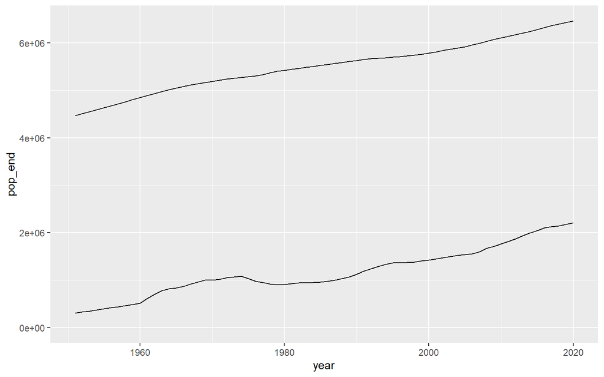

```r
ggplot(mapping = aes(x = year)) +
  geom_line(swiss, mapping = aes(y = pop_end)) +
  geom_line(non_swiss, mapping = aes(y = pop_end)) +
  expand_limits(y = 0)
```

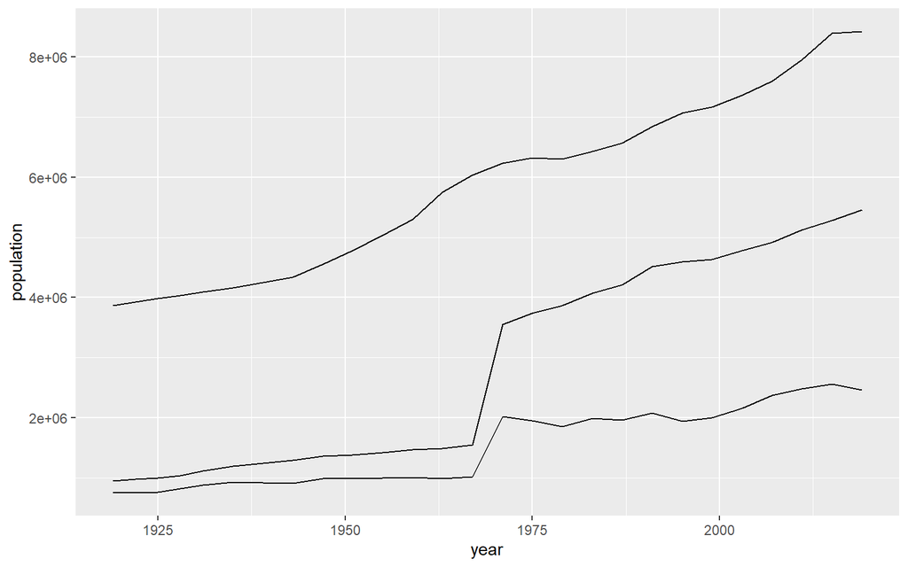

```r
voters %>%
  ggplot(mapping = aes(x=year)) +
  geom_line(mapping = aes(y = population)) +
  geom_line(mapping = aes(y = right_to_vote)) +
  geom_line(mapping = aes(y = voting))
```

you can easily see when women were added to the pool of people allowed to vote! plus the plateau of the latest total population value, which apparently was 3 years behind (i.e. really is the value of 2016 rather than 2019)

not yet ideal. more data-munching:

combine swiss and non-swiss into the same tibble and calculate total

```r
pop <- swiss %>%
  full_join(non_swiss, by = "year", suffix = c("_ch", "_non_ch")) %>%
  mutate(sum_end = pop_end_ch + pop_end_non_ch) %>%
  mutate(sum_beginning = pop_beginning_ch + pop_beginning_non_ch)
glimpse(pop)
```

```
## Rows: 68
## Columns: 7
## $ year                 <int> 1951, 1952, 1953, 1954, 1955, 1956, 1957, 1958, 1~
## $ pop_beginning_ch     <dbl> 4432100, 4470800, 4513200, 4553100, 4593500, 4634~
## $ pop_end_ch           <dbl> 4470800, 4513200, 4553100, 4593500, 4634000, 4674~
## $ pop_beginning_non_ch <dbl> 285100, 308100, 330900, 353900, 376800, 399700, 4~
## $ pop_end_non_ch       <dbl> 308100, 330900, 353900, 376800, 399700, 422500, 4~
## $ sum_end              <dbl> 4778900, 4844100, 4907000, 4970300, 5033700, 5097~
## $ sum_beginning        <dbl> 4717200, 4778900, 4844100, 4907000, 4970300, 5033~
```

but long format would be easier!

```r
# let's only take the end-of-year values
pop <- pop %>%
  select(!contains("beginning")) %>%
  rename(ch = pop_end_ch, non_ch = pop_end_non_ch, total = sum_end)

pop_long <- pop %>%
  pivot_longer(cols = !year,names_to = "category", values_to = "population")
```

and quick plot

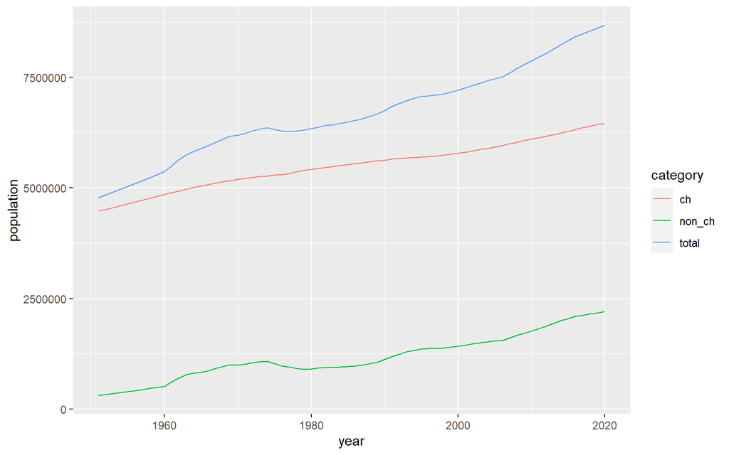

```r
pop_long %>%
  ggplot(mapping = aes(x = year, y = population, color = category)) +
  geom_line()
```

have this as a stacked area plot

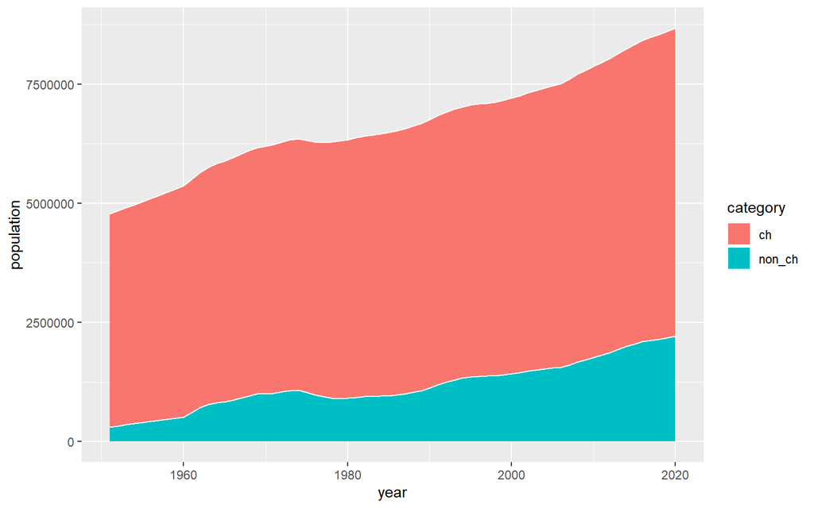

```r
pop_long %>%
  filter(category != "total") %>%
  ggplot(mapping = aes(x = year, y = population, fill = category)) +
  geom_area(color="white")
```

I should convert the category to a factor

```r
pop_long <- pop_long %>%
  filter(category != "total") %>%
  mutate(category = factor(category, levels = c("ch", "non_ch")))
```

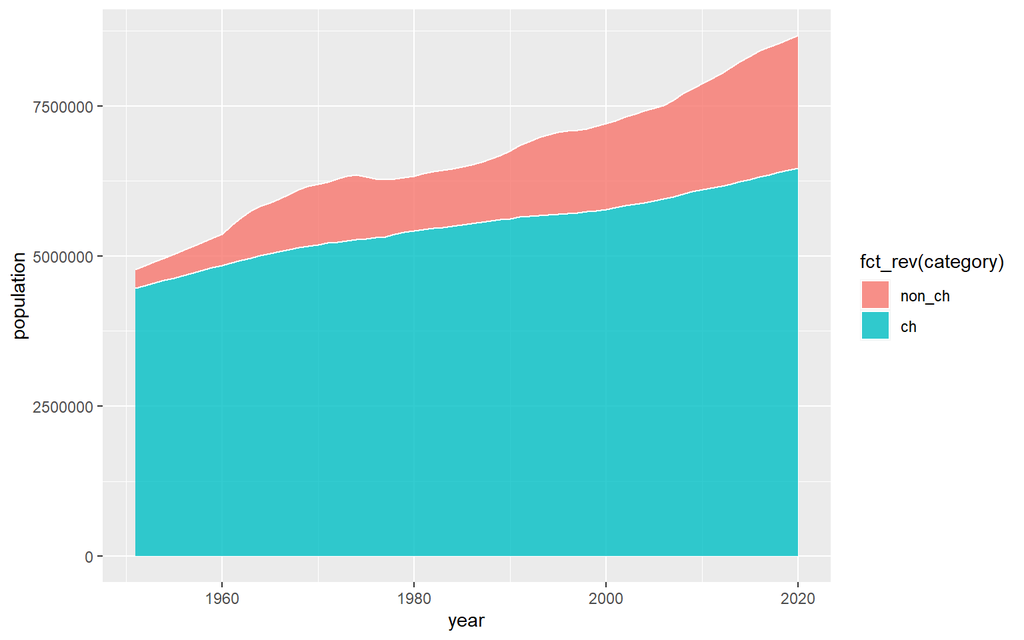

```r
pop_long %>%
  ggplot(mapping = aes(x = year, y = population, fill = fct_rev(category))) +
  geom_area(size=.5, colour="white", position="stack", alpha=0.8)
```

put the voters in there as well to see how well the total population numbers align:

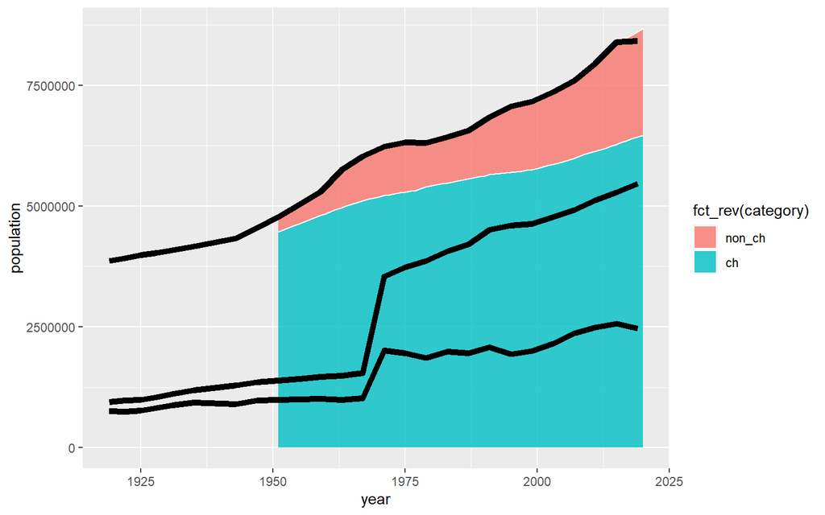

```r
pop_long %>%
  ggplot(mapping = aes(x = year)) +
  geom_area(mapping = aes(y = population, fill = fct_rev(category)),
            size=.5, colour="white", position="stack", alpha=0.8) +
  geom_line(voters, mapping = aes(y = population), color="black", size = 2) +
  geom_line(voters, mapping = aes(y = voting), size = 2) +
  geom_line(voters, mapping = aes(x = year, y = right_to_vote), size = 2)
```

total population from the voters tibble and from the swiss and non swiss nationals is close enough - take only the latter

use `{scales}` [package](https://scales.r-lib.org/reference/index.html) is quite for improving the tick labels! apply both a formatting (using the tick as a thousand separator) and a scale (showing 1000 rather than 1 people per unit)

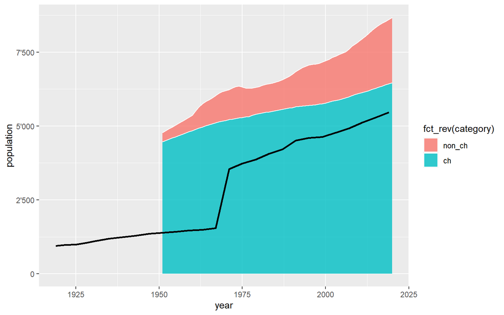

```r
pop_long %>%
  ggplot(mapping = aes(x = year)) +
  geom_area(mapping = aes(y = population, fill = fct_rev(category)),
            size=.5, colour="white", position="stack", alpha=0.8) +
  geom_line(voters, mapping = aes(y = right_to_vote), size = 1, color = "black") +
  scale_y_continuous(labels = label_comma(big.mark = "'", scale = 0.001))
```

filter the voters so that also only data since 1951 is shown and add it to the combo tibble

need to split the CH category, otherwise the sum will not be right anymore

```r
temp_voters <- voters %>%
  filter(year > 1950) %>%
  select(year, right_to_vote)

combo_wide <- pop %>%
  filter(year %in% voters$year) %>%
  select(-total) %>%
  left_join(temp_voters, by = "year") %>%
  mutate(ch_no_right = ch - right_to_vote) %>%
  rename(ch_right = right_to_vote) %>%
  select(-ch)

combo_long <- combo_wide %>%
  pivot_longer(cols = c("non_ch", "ch_right", "ch_no_right"),
               names_to = "category",
               values_to = "population") %>%
  mutate(category = fct_relevel(factor(category), c("ch_right", "ch_no_right", "non_ch")))
```

## first time basic plot reached

plot with better labels

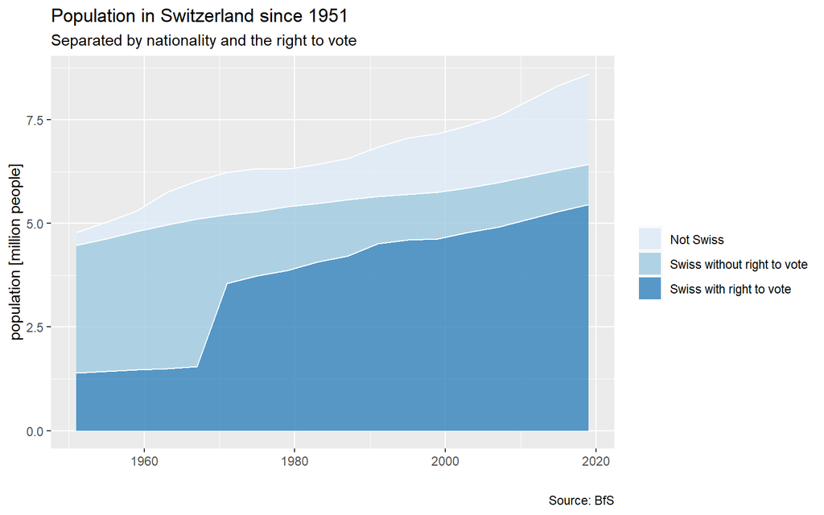

```r
combo_long %>%
  ggplot(mapping = aes(x = year, y = population, fill = fct_rev(category))) +
  geom_area(size=.5, colour="white", position="stack", alpha=0.8) +
  #geom_line(voters_to_plot, mapping = aes(y = right_to_vote), size = 1, color = "black") +
  scale_y_continuous(labels = label_comma(big.mark = "'", scale = 0.000001)) +
  scale_fill_brewer(labels = c("Not Swiss", "Swiss without right to vote", "Swiss with right to vote")) +
  guides(fill = guide_legend(title = "")) +
  labs(title = "Population in Switzerland since 1951",
       subtitle = "Separated by nationality and the right to vote",
       x = "",
       y = "population [million people]",
       caption = "Source: BfS")
```

much better!

## Add annotation

highlighting when women got the right to vote

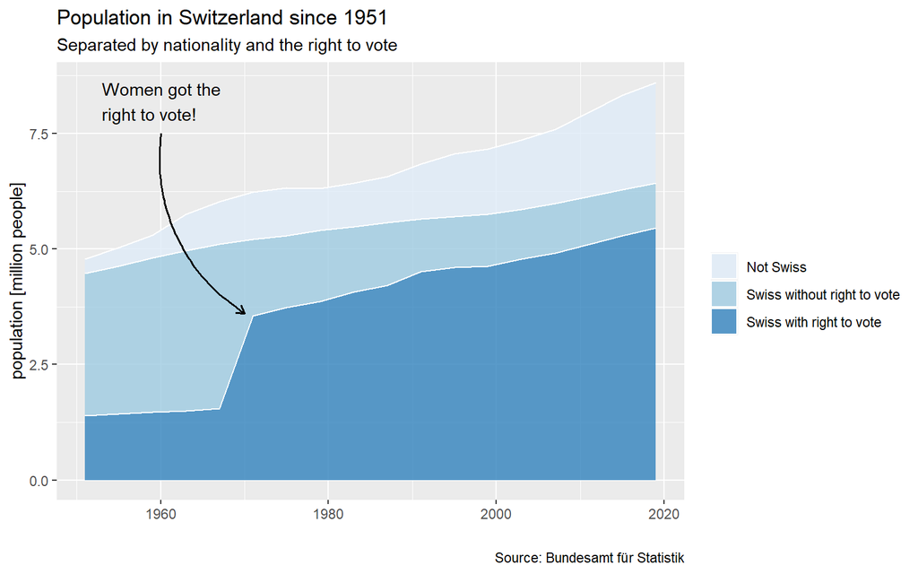

```r
p <- combo_long %>%
  ggplot(mapping = aes(x = year, y = population, fill = fct_rev(category))) +
  geom_area(size=.5, colour="white", position="stack", alpha=0.8) +
  annotate(geom = "curve", x = 1960, xend = 1970, y = 7500000, yend = 3600000,
           curvature = 0.3, arrow = arrow(length = unit(2, "mm")), size=0.7) +
  annotate(geom = "text", x = 1953, y = 8200000, label = "Women got the \nright to vote!",
           hjust = "left", color="black") +
  scale_y_continuous(labels = label_comma(big.mark = "'", scale = 0.000001)) +
  labs(title = "Population in Switzerland since 1951",
       subtitle = "Separated by nationality and the right to vote",
       x = "",
       y = "population [million people]",
       caption = "Source: Bundesamt für Statistik")
p + scale_fill_brewer(labels = c("Not Swiss", "Swiss without right to vote", "Swiss with right to vote")) +
  guides(fill = guide_legend(title = ""))
```

## Play around with different themes

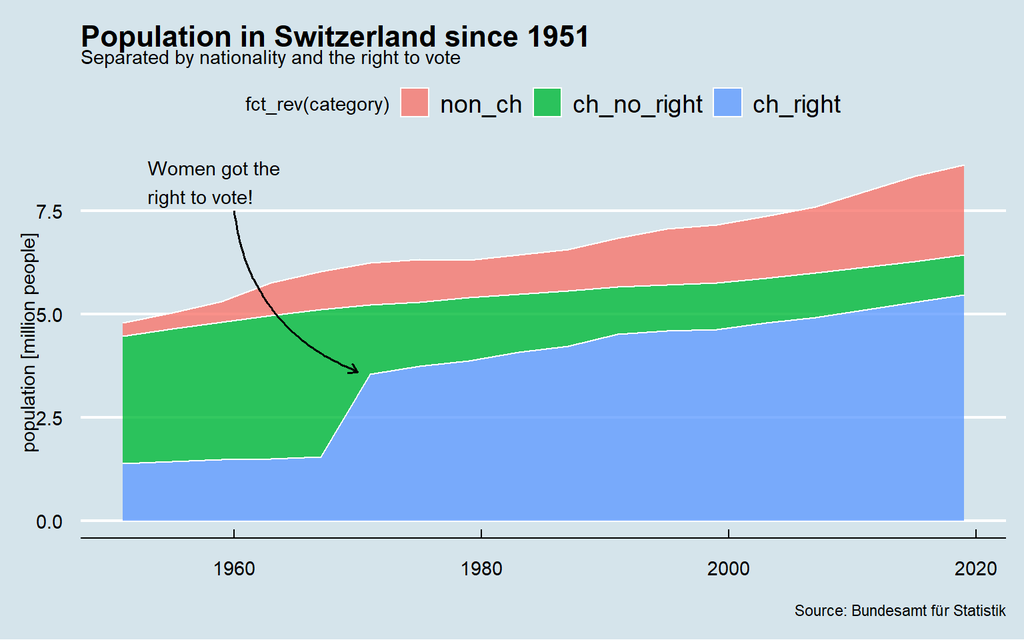

```r
p + ggthemes::theme_economist()
```

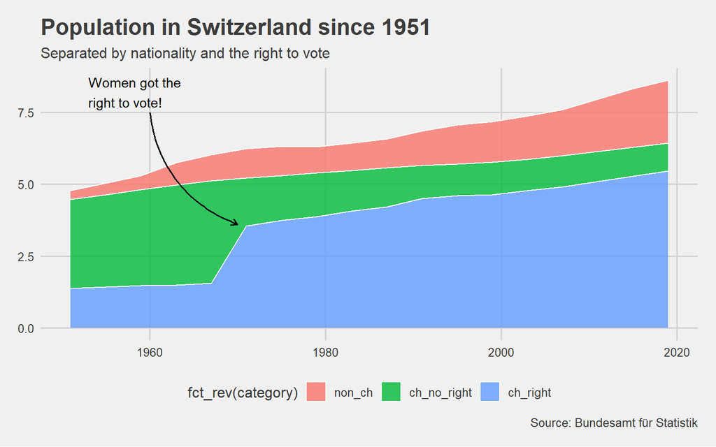

```r
p + ggthemes::theme_fivethirtyeight()
```

Additional themes from `{ggthemr}` package. This is not on CRAN yet so has to be installed with `devtools::install_github('Mikata-Project/ggthemr')`

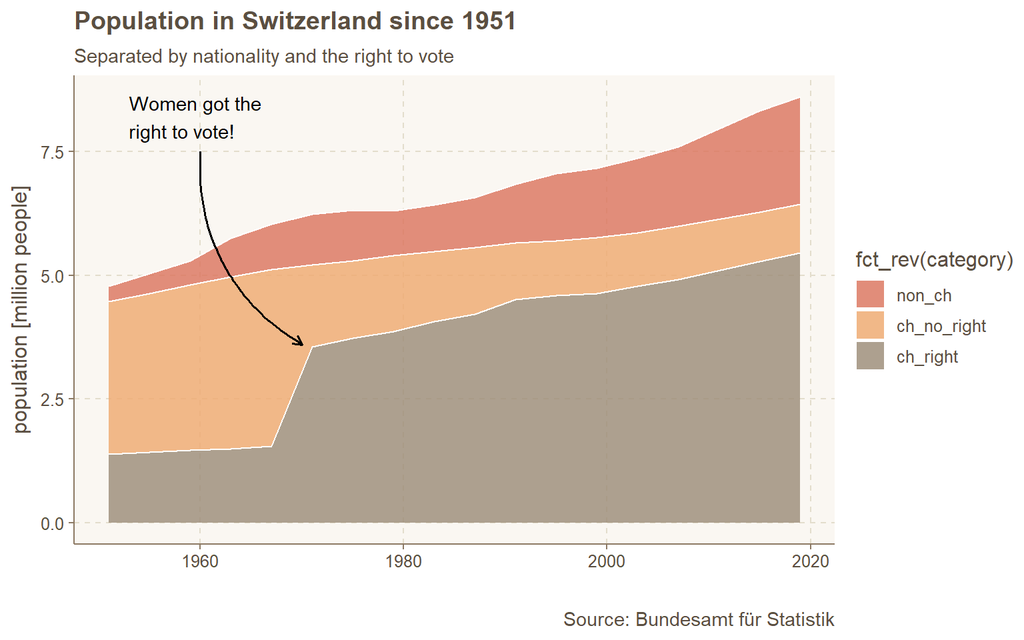

```r
ggthemr::ggthemr("dust")
p
```

I quite like this one! Will need some tweaks though

## Play around with legend

First, need to improve the legend labels

the `{ggthemr}` package has a `scale_color_ggthemr_d` function, but none for the fill. As I also would like to change the order of the colors, I’ll manually extract the colors from a plot above with a colorpicker and add it with a manual color scale

```r
my_colors <- rev(c("#ADA08F", "#E18D7A", "#F1B888"))
my_labels <- c("Not Swiss", "Swiss without right to vote", "Swiss with right to vote")
```

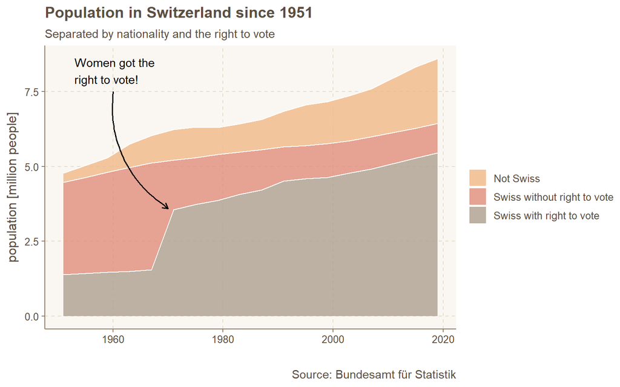

```r
q <- p + scale_fill_manual(values = my_colors, labels = my_labels) +
  guides(fill = guide_legend(title = ""))

q
```

Now the legend on the right hand side takes a lot of space, and creates a lot of whitespace. Could change this by placing the legend above the plot

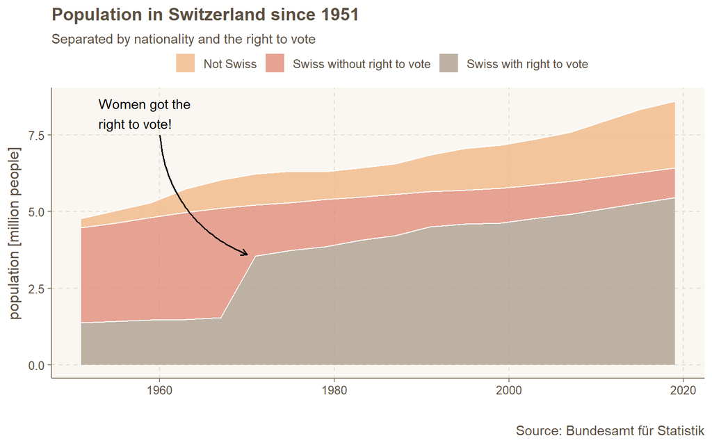

```r
q + theme(legend.position = "top")
```

or below the plot

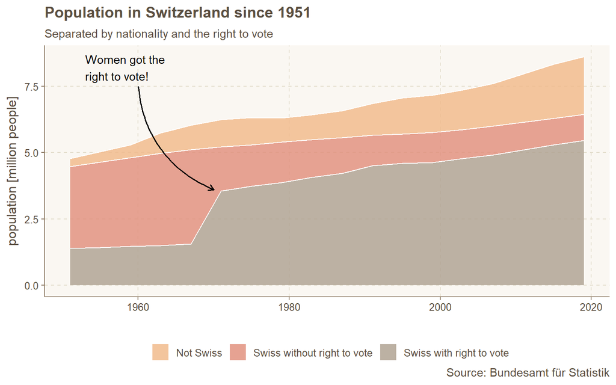

```r
q + theme(legend.position = "bottom")
```

or in the subtitle - try that below

## more modifications

### color of the annotation

now the black stands out, make it the same color as the font of the theme (again with manual colorpick)

```r
color_font <- "#5B4F41"
```

actually change it below

## whole plot in one go

repeat everything needed

```r
my_colors <- c("#ADA08F", "#E18D7A", "#F1B888")
my_labels <- c("Not Swiss", "Swiss without right to vote", "Swiss with right to vote")
```

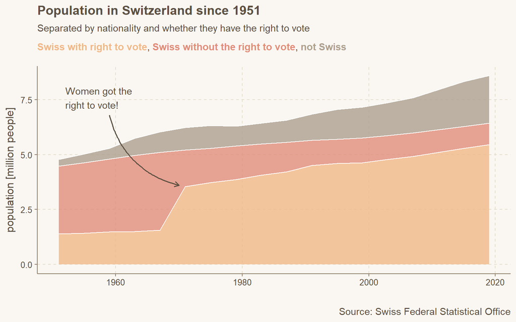

```r
ggthemr::ggthemr("dust", type = "outer")
combo_long %>%
  ggplot(mapping = aes(x = year, y = population, fill = fct_rev(category))) +
  geom_area(size=.5, colour="white", position="stack", alpha=0.8) +
  annotate(geom = "curve", x = 1959, xend = 1970, y = 6800000, yend = 3600000,
           curvature = 0.3, arrow = arrow(length = unit(2, "mm")), size=0.7,
           color=color_font) +
  annotate(geom = "text", x = 1952, y = 7600000, label = "Women got the \nright to vote!",
           hjust = "left", color=color_font) +
  scale_y_continuous(labels = label_comma(big.mark = "'", scale = 0.000001)) +
  labs(title = "Population in Switzerland since 1951",
       subtitle = "Separated by nationality and whether they have the right to vote<br> <br>
       <b style='color:#F1B888'> Swiss with right to vote</b>,  <b style='color:#E18D7A'>Swiss without the right to vote</b>, <b style='color:#ADA08F'>not Swiss</b> <br>",
       x = "",
       y = "population [million people]",
       caption = "Source: Swiss Federal Statistical Office") +
  scale_fill_manual(values = my_colors, labels = my_labels) +
  guides(fill = guide_legend(title = "")) +
  theme(plot.subtitle = ggtext::element_markdown(),
        legend.position = "none")
```

actually too much text to have it in color - go back to normal legend

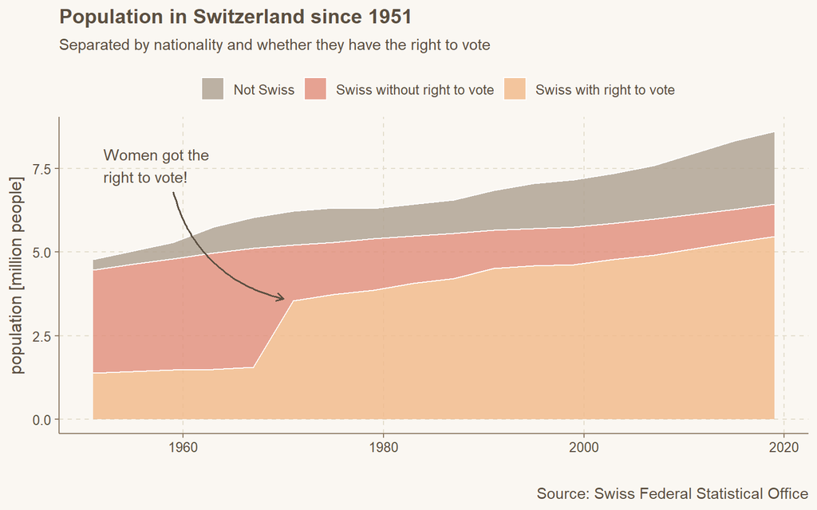

```r
ggthemr::ggthemr("dust", type = "outer")
combo_long %>%
  ggplot(mapping = aes(x = year, y = population, fill = fct_rev(category))) +
  geom_area(size=.5, colour="white", position="stack", alpha=0.8) +
  annotate(geom = "curve", x = 1959, xend = 1970, y = 6800000, yend = 3600000,
           curvature = 0.3, arrow = arrow(length = unit(2, "mm")), size=0.7,
           color=color_font) +
  annotate(geom = "text", x = 1952, y = 7600000, label = "Women got the \nright to vote!",
           hjust = "left", color=color_font) +
  scale_y_continuous(labels = label_comma(big.mark = "'", scale = 0.000001)) +
  labs(title = "Population in Switzerland since 1951",
       subtitle = "Separated by nationality and whether they have the right to vote\n",
       x = "",
       y = "population [million people]",
       caption = "Source: Swiss Federal Statistical Office") +
  scale_fill_manual(values = my_colors, labels = my_labels) +
  guides(fill = guide_legend(title = "")) +
  theme(legend.position = "top")
```

and which way round to have the colors? the way it is above, the orange/red colors show people with a Swiss passport, and the ‘outgroup’ of the foreigners is separated also by color

however, I could also reverse it:

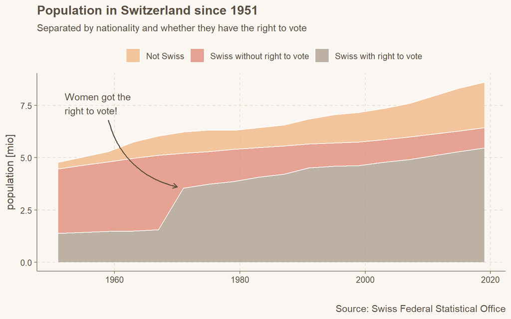

```r
ggthemr::ggthemr("dust", type = "outer")
combo_long %>%
  ggplot(mapping = aes(x = year, y = population, fill = fct_rev(category))) +
  geom_area(size=.5, colour="white", position="stack", alpha=0.8) +
  annotate(geom = "curve", x = 1959, xend = 1970, y = 6800000, yend = 3600000,
           curvature = 0.3, arrow = arrow(length = unit(2, "mm")), size=0.7,
           color=color_font) +
  annotate(geom = "text", x = 1952, y = 7600000, label = "Women got the \nright to vote!",
           hjust = "left", color=color_font) +
  scale_y_continuous(labels = label_comma(big.mark = "'", scale = 0.000001)) +
  labs(title = "Population in Switzerland since 1951",
       subtitle = "Separated by nationality and whether they have the right to vote\n",
       x = "",
       y = "population [mio]",
       caption = "Source: Swiss Federal Statistical Office") +
  scale_fill_manual(values = rev(my_colors), labels = my_labels) +
  guides(fill = guide_legend(title = "")) +
  theme(legend.position = "top")
```

I like here that the darkest color is at the bottom - I think this is prettier to look at in terms of the plot itself. It does somehow group the swiss without the right to vote and the non-Swiss, in opposition to the Swiss people with the right to vote… maybe strange in terms of nationality but since I am also highlighting the increase in the voter group, I think it is ok. I will got with this one

## Final plot

also align title and subtitle differently and make the font size of the caption smaller

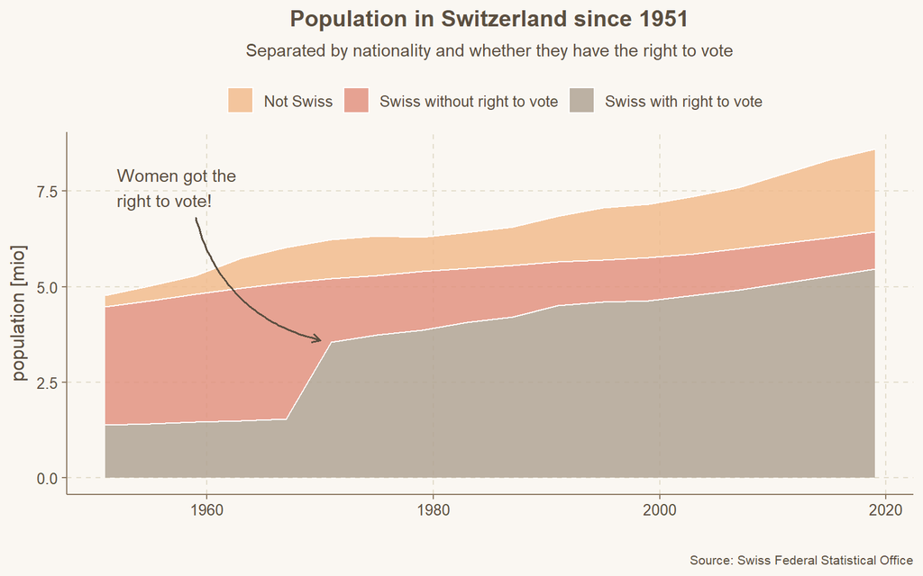

```r
ggthemr::ggthemr("dust", type = "outer")
final_plot <- combo_long %>%
  ggplot(mapping = aes(x = year, y = population, fill = fct_rev(category))) +
  geom_area(size=.5, colour="white", position="stack", alpha=0.8) +
  annotate(geom = "curve", x = 1959, xend = 1970, y = 6800000, yend = 3600000,
           curvature = 0.3, arrow = arrow(length = unit(2, "mm")), size=0.7,
           color=color_font) +
  annotate(geom = "text", x = 1952, y = 7600000, label = "Women got the \nright to vote!",
           hjust = "left", color=color_font) +
  scale_y_continuous(labels = label_comma(big.mark = "'", scale = 0.000001)) +
  labs(title = "Population in Switzerland since 1951",
       subtitle = "Separated by nationality and whether they have the right to vote\n",
       x = "",
       y = "population [mio]",
       caption = "Source: Swiss Federal Statistical Office") +
  scale_fill_manual(values = rev(my_colors), labels = my_labels) +
  guides(fill = guide_legend(title = "")) +
  theme(legend.position = "top",
        plot.title = element_text(hjust=0.5),
        plot.subtitle = element_text(hjust = 0.5),
        plot.caption = element_text(size = 8))
final_plot
```

```r
ggsave("Swiss_pop_1951_2019.png", dpi=300, width=7, height=6)
```

## Open points

- I am not entirely happy about the y axis label
- somewhat questionable whether instead of reducing the population data to once every 4 years, I should have filled the voter data to every year. however, filling seems more (potentially) wrong than leaving out, so left it as is.

## Calculate some values to be mentioned

```r
# get values to be highlighted below
combo_wide <- combo_wide %>%
  mutate(total = non_ch + ch_right + ch_no_right)

# overall population increase
pop_1951 <- combo_wide %>% filter(year == 1951) %>% pull(total)
pop_2019 <- combo_wide %>% filter(year == 2019) %>% pull(total)
total_increase <- (pop_2019 - pop_1951) / pop_1951 * 100

# ch vs non_ch population increase
pop_ch_1951 <- combo_wide %>% filter(year == 1951) %>% mutate(total_ch = ch_right + ch_no_right) %>% pull(total_ch)
pop_non_ch_1951 <- combo_wide %>% filter(year == 1951) %>% pull(non_ch)
pop_ch_2019 <- combo_wide %>% filter(year == 2019) %>% mutate(total_ch = ch_right + ch_no_right) %>% pull(total_ch)
pop_non_ch_2019 <- combo_wide %>% filter(year == 2019) %>% pull(non_ch)
increase_ch <- (pop_ch_2019 - pop_ch_1951) / pop_ch_1951 * 100
increase_non_ch <- (pop_non_ch_2019 - pop_non_ch_1951) / pop_non_ch_1951 * 100

# status 2019
prop_non_swiss_2019 <- combo_wide %>% filter(year==2019) %>% mutate(prop = non_ch/total) %>% pull(prop)

# women get the right to vote
men_only <- combo_wide %>% filter(year == 1967) %>% pull(ch_right)
right_to_vote_1971 <- combo_wide %>% filter(year == 1971) %>% pull(ch_right)

# change in CH since late seventies
pop_ch_1979 <- combo_wide %>% filter(year == 1979) %>% mutate(total_ch = ch_right + ch_no_right) %>% pull(total_ch)
increase_ch_1979_2019 <- (pop_ch_2019 - pop_ch_1979) / pop_ch_1979 *100
```

### Some extra links not used:

*Number of signatures required as comparison*

- 100’000 for a federal popular initiative (‘Volksinitiative’, see [here](https://www.ch.ch/en/political-system/political-rights/initiatives/how-to-launch-a-federal-initiative/)); has been 100’000 since 1977, 50’000 before ([historisches Lexikon der Schweiz: Volksinitiative](https://hls-dhs-dss.ch/de/articles/010386/2016-07-18/))
- 50’000 for an optional referendum (i.e. getting a vote on something parliament has recently decided, see [here](https://www.ch.ch/en/political-system/political-rights/referendums/mandatory-and-optional-referendums/)); has been 50’000 since 1978 ([historisches Lexikon der Schweiz: Referendum](https://hls-dhs-dss.ch/de/articles/010387/2011-12-23/))

*other extra stuff*

- to be correct would have to add the Swiss living abroad…[Auslandschweizer in 2019](https://www.pxweb.bfs.admin.ch/sq/1f84b174-583c-45cb-a52e-c6fa8fa8bf78)
- Lebenserwartung [hier](https://www.bfs.admin.ch/bfs/de/home/statistiken/bevoelkerung/geburten-todesfaelle/lebenserwartung.assetdetail.18845607.html)